# Airline On-Time Performance Data

```r
library(tidyverse)
library(mosaic)
library(Lahman)
library(nycflights13)
library(skimr)
```

##Read the.csv files :

```r
Calfornia201801<- read_csv(
  file="CA Jan.csv")
Calfornia201802<- read_csv(
  file="CA Feb.csv")
Calfornia201803<- read_csv(
  file="CA March.csv")
Calfornia201804<- read_csv(
  file="CA April.csv")
Calfornia201805<- read_csv(file="CA May.csv")
Calfornia201806<- read_csv(file="CA JUNE.csv")
Calfornia201807<- read_csv(file="CA JULY.csv")
```

##2.Extract the flights that departed from the Bay Area. Include all flights departing from San Francisco, Oakland, and San Jose and find the flights in January 2018 .

##After extracting all the flights departing from SFO ,OAK,SJC , there were total of 22606 flights in January 2018 . There were 14135 flights from “SFO” , 4277 flights from “SJC” and 4194 flights from “OAK” .

```r
Calfornia201801
```

| YEAR | MONTH | DAY_OF_MONTH | FL_DATE | TAIL_NUM | OP_CARRIER_FL_NUM | ORIGIN_AIRPORT_ID | ORIGIN_AIRPORT_SEQ_ID | ORIGIN | ORIGIN_CITY_NAME | ORIGIN_STATE_NM | DEST_AIRPORT_ID | DEST_AIRPORT_SEQ_ID | DEST | DEST_CITY_NAME | DEST_STATE_NM | DEP_TIME | DEP_DELAY | ARR_TIME | ARR_DELAY | AIR_TIME | FLIGHTS | DISTANCE | X24 |
| --- | --- | --- | --- | --- | --- | --- | --- | --- | --- | --- | --- | --- | --- | --- | --- | --- | --- | --- | --- | --- | --- | --- | --- |
| 2018 | 1 | 27 | 2018-01-27 | N477UA | 368 | 14747 | 1474703 | SEA | Seattle, WA | Washington | 14771 | 1477104 | SFO | San Francisco, CA | California | 0614 | -4 | 0813 | -18 | 98 | 1 | 679 | NA |
| 2018 | 1 | 27 | 2018-01-27 | N16217 | 366 | 12892 | 1289208 | LAX | Los Angeles, CA | California | 13930 | 1393006 | ORD | Chicago, IL | Illinois | 0641 | -9 | 1242 | -8 | 212 | 1 | 1744 | NA |
| 2018 | 1 | 27 | 2018-01-27 | N37255 | 361 | 12889 | 1288903 | LAS | Las Vegas, NV | Nevada | 14771 | 1477104 | SFO | San Francisco, CA | California | 1515 | -5 | 1641 | -22 | 68 | 1 | 414 | NA |
| 2018 | 1 | 27 | 2018-01-27 | N424UA | 360 | 12892 | 1289208 | LAX | Los Angeles, CA | California | 12264 | 1226402 | IAD | Washington, DC | Virginia | 0804 | -6 | 1548 | -14 | 256 | 1 | 2288 | NA |
| 2018 | 1 | 27 | 2018-01-27 | N36469 | 358 | 14771 | 1477104 | SFO | San Francisco, CA | California | 12889 | 1288903 | LAS | Las Vegas, NV | Nevada | 1033 | -9 | 1208 | -13 | 62 | 1 | 414 | NA |
| 2018 | 1 | 27 | 2018-01-27 | N835UA | 346 | 14831 | 1483106 | SJC | San Jose, CA | California | 13930 | 1393006 | ORD | Chicago, IL | Illinois | 1342 | -18 | 1944 | -23 | 218 | 1 | 1829 | NA |
| 2018 | 1 | 27 | 2018-01-27 | N76503 | 341 | 14679 | 1467903 | SAN | San Diego, CA | California | 12266 | 1226603 | IAH | Houston, TX | Texas | 0933 | -7 | 1428 | -22 | 153 | 1 | 1303 | NA |
| 2018 | 1 | 27 | 2018-01-27 | N69810 | 340 | 12264 | 1226402 | IAD | Washington, DC | Virginia | 14771 | 1477104 | SFO | San Francisco, CA | California | 1727 | -8 | 2016 | -31 | 332 | 1 | 2419 | NA |
| 2018 | 1 | 27 | 2018-01-27 | N76288 | 338 | 11292 | 1129202 | DEN | Denver, CO | Colorado | 14262 | 1426204 | PSP | Palm Springs, CA | California | 1921 | -4 | 2023 | -20 | 106 | 1 | 776 | NA |
| 2018 | 1 | 27 | 2018-01-27 | N67846 | 325 | 12892 | 1289208 | LAX | Los Angeles, CA | California | 12889 | 1288903 | LAS | Las Vegas, NV | Nevada | 2308 | -8 | 0014 | -16 | 45 | 1 | 236 | NA |

[output cut: 990 more lines]

```r
Calfornia201801 %>% filter(ORIGIN == "SFO" | ORIGIN == "SJC" | ORIGIN == "OAK" ) %>%
    count()
```

| n |
| --- |
| 22606 |

```r
NA
```

14135 flights from “SFO”

```r
Calfornia201801
```

| YEAR | MONTH | DAY_OF_MONTH | FL_DATE | TAIL_NUM | OP_CARRIER_FL_NUM | ORIGIN_AIRPORT_ID | ORIGIN_AIRPORT_SEQ_ID | ORIGIN | ORIGIN_CITY_NAME | ORIGIN_STATE_NM | DEST_AIRPORT_ID | DEST_AIRPORT_SEQ_ID | DEST | DEST_CITY_NAME | DEST_STATE_NM | DEP_TIME | DEP_DELAY | ARR_TIME | ARR_DELAY | AIR_TIME | FLIGHTS | DISTANCE | X24 |
| --- | --- | --- | --- | --- | --- | --- | --- | --- | --- | --- | --- | --- | --- | --- | --- | --- | --- | --- | --- | --- | --- | --- | --- |
| 2018 | 1 | 27 | 2018-01-27 | N477UA | 368 | 14747 | 1474703 | SEA | Seattle, WA | Washington | 14771 | 1477104 | SFO | San Francisco, CA | California | 0614 | -4 | 0813 | -18 | 98 | 1 | 679 | NA |
| 2018 | 1 | 27 | 2018-01-27 | N16217 | 366 | 12892 | 1289208 | LAX | Los Angeles, CA | California | 13930 | 1393006 | ORD | Chicago, IL | Illinois | 0641 | -9 | 1242 | -8 | 212 | 1 | 1744 | NA |
| 2018 | 1 | 27 | 2018-01-27 | N37255 | 361 | 12889 | 1288903 | LAS | Las Vegas, NV | Nevada | 14771 | 1477104 | SFO | San Francisco, CA | California | 1515 | -5 | 1641 | -22 | 68 | 1 | 414 | NA |
| 2018 | 1 | 27 | 2018-01-27 | N424UA | 360 | 12892 | 1289208 | LAX | Los Angeles, CA | California | 12264 | 1226402 | IAD | Washington, DC | Virginia | 0804 | -6 | 1548 | -14 | 256 | 1 | 2288 | NA |
| 2018 | 1 | 27 | 2018-01-27 | N36469 | 358 | 14771 | 1477104 | SFO | San Francisco, CA | California | 12889 | 1288903 | LAS | Las Vegas, NV | Nevada | 1033 | -9 | 1208 | -13 | 62 | 1 | 414 | NA |
| 2018 | 1 | 27 | 2018-01-27 | N835UA | 346 | 14831 | 1483106 | SJC | San Jose, CA | California | 13930 | 1393006 | ORD | Chicago, IL | Illinois | 1342 | -18 | 1944 | -23 | 218 | 1 | 1829 | NA |
| 2018 | 1 | 27 | 2018-01-27 | N76503 | 341 | 14679 | 1467903 | SAN | San Diego, CA | California | 12266 | 1226603 | IAH | Houston, TX | Texas | 0933 | -7 | 1428 | -22 | 153 | 1 | 1303 | NA |
| 2018 | 1 | 27 | 2018-01-27 | N69810 | 340 | 12264 | 1226402 | IAD | Washington, DC | Virginia | 14771 | 1477104 | SFO | San Francisco, CA | California | 1727 | -8 | 2016 | -31 | 332 | 1 | 2419 | NA |
| 2018 | 1 | 27 | 2018-01-27 | N76288 | 338 | 11292 | 1129202 | DEN | Denver, CO | Colorado | 14262 | 1426204 | PSP | Palm Springs, CA | California | 1921 | -4 | 2023 | -20 | 106 | 1 | 776 | NA |
| 2018 | 1 | 27 | 2018-01-27 | N67846 | 325 | 12892 | 1289208 | LAX | Los Angeles, CA | California | 12889 | 1288903 | LAS | Las Vegas, NV | Nevada | 2308 | -8 | 0014 | -16 | 45 | 1 | 236 | NA |

[output cut: 990 more lines]

```r
Calfornia201801 %>% filter (ORIGIN == "SFO" )%>%
  count()
```

| n |
| --- |
| 14135 |

```r
NA
NA
```

4277 flights from “SJC”

```r
Calfornia201801
```

| YEAR | MONTH | DAY_OF_MONTH | FL_DATE | TAIL_NUM | OP_CARRIER_FL_NUM | ORIGIN_AIRPORT_ID | ORIGIN_AIRPORT_SEQ_ID | ORIGIN | ORIGIN_CITY_NAME | ORIGIN_STATE_NM | DEST_AIRPORT_ID | DEST_AIRPORT_SEQ_ID | DEST | DEST_CITY_NAME | DEST_STATE_NM | DEP_TIME | DEP_DELAY | ARR_TIME | ARR_DELAY | AIR_TIME | FLIGHTS | DISTANCE | X24 |
| --- | --- | --- | --- | --- | --- | --- | --- | --- | --- | --- | --- | --- | --- | --- | --- | --- | --- | --- | --- | --- | --- | --- | --- |
| 2018 | 1 | 27 | 2018-01-27 | N477UA | 368 | 14747 | 1474703 | SEA | Seattle, WA | Washington | 14771 | 1477104 | SFO | San Francisco, CA | California | 0614 | -4 | 0813 | -18 | 98 | 1 | 679 | NA |
| 2018 | 1 | 27 | 2018-01-27 | N16217 | 366 | 12892 | 1289208 | LAX | Los Angeles, CA | California | 13930 | 1393006 | ORD | Chicago, IL | Illinois | 0641 | -9 | 1242 | -8 | 212 | 1 | 1744 | NA |
| 2018 | 1 | 27 | 2018-01-27 | N37255 | 361 | 12889 | 1288903 | LAS | Las Vegas, NV | Nevada | 14771 | 1477104 | SFO | San Francisco, CA | California | 1515 | -5 | 1641 | -22 | 68 | 1 | 414 | NA |
| 2018 | 1 | 27 | 2018-01-27 | N424UA | 360 | 12892 | 1289208 | LAX | Los Angeles, CA | California | 12264 | 1226402 | IAD | Washington, DC | Virginia | 0804 | -6 | 1548 | -14 | 256 | 1 | 2288 | NA |
| 2018 | 1 | 27 | 2018-01-27 | N36469 | 358 | 14771 | 1477104 | SFO | San Francisco, CA | California | 12889 | 1288903 | LAS | Las Vegas, NV | Nevada | 1033 | -9 | 1208 | -13 | 62 | 1 | 414 | NA |
| 2018 | 1 | 27 | 2018-01-27 | N835UA | 346 | 14831 | 1483106 | SJC | San Jose, CA | California | 13930 | 1393006 | ORD | Chicago, IL | Illinois | 1342 | -18 | 1944 | -23 | 218 | 1 | 1829 | NA |
| 2018 | 1 | 27 | 2018-01-27 | N76503 | 341 | 14679 | 1467903 | SAN | San Diego, CA | California | 12266 | 1226603 | IAH | Houston, TX | Texas | 0933 | -7 | 1428 | -22 | 153 | 1 | 1303 | NA |
| 2018 | 1 | 27 | 2018-01-27 | N69810 | 340 | 12264 | 1226402 | IAD | Washington, DC | Virginia | 14771 | 1477104 | SFO | San Francisco, CA | California | 1727 | -8 | 2016 | -31 | 332 | 1 | 2419 | NA |
| 2018 | 1 | 27 | 2018-01-27 | N76288 | 338 | 11292 | 1129202 | DEN | Denver, CO | Colorado | 14262 | 1426204 | PSP | Palm Springs, CA | California | 1921 | -4 | 2023 | -20 | 106 | 1 | 776 | NA |
| 2018 | 1 | 27 | 2018-01-27 | N67846 | 325 | 12892 | 1289208 | LAX | Los Angeles, CA | California | 12889 | 1288903 | LAS | Las Vegas, NV | Nevada | 2308 | -8 | 0014 | -16 | 45 | 1 | 236 | NA |

[output cut: 990 more lines]

```r
Calfornia201801 %>% filter (ORIGIN == "SJC" )%>%
  count()
```

| n |
| --- |
| 4277 |

4194 flights from “OAK” .

```r
Calfornia201801
```

| YEAR | MONTH | DAY_OF_MONTH | FL_DATE | TAIL_NUM | OP_CARRIER_FL_NUM | ORIGIN_AIRPORT_ID | ORIGIN_AIRPORT_SEQ_ID | ORIGIN | ORIGIN_CITY_NAME | ORIGIN_STATE_NM | DEST_AIRPORT_ID | DEST_AIRPORT_SEQ_ID | DEST | DEST_CITY_NAME | DEST_STATE_NM | DEP_TIME | DEP_DELAY | ARR_TIME | ARR_DELAY | AIR_TIME | FLIGHTS | DISTANCE | X24 |
| --- | --- | --- | --- | --- | --- | --- | --- | --- | --- | --- | --- | --- | --- | --- | --- | --- | --- | --- | --- | --- | --- | --- | --- |
| 2018 | 1 | 27 | 2018-01-27 | N477UA | 368 | 14747 | 1474703 | SEA | Seattle, WA | Washington | 14771 | 1477104 | SFO | San Francisco, CA | California | 0614 | -4 | 0813 | -18 | 98 | 1 | 679 | NA |
| 2018 | 1 | 27 | 2018-01-27 | N16217 | 366 | 12892 | 1289208 | LAX | Los Angeles, CA | California | 13930 | 1393006 | ORD | Chicago, IL | Illinois | 0641 | -9 | 1242 | -8 | 212 | 1 | 1744 | NA |
| 2018 | 1 | 27 | 2018-01-27 | N37255 | 361 | 12889 | 1288903 | LAS | Las Vegas, NV | Nevada | 14771 | 1477104 | SFO | San Francisco, CA | California | 1515 | -5 | 1641 | -22 | 68 | 1 | 414 | NA |
| 2018 | 1 | 27 | 2018-01-27 | N424UA | 360 | 12892 | 1289208 | LAX | Los Angeles, CA | California | 12264 | 1226402 | IAD | Washington, DC | Virginia | 0804 | -6 | 1548 | -14 | 256 | 1 | 2288 | NA |
| 2018 | 1 | 27 | 2018-01-27 | N36469 | 358 | 14771 | 1477104 | SFO | San Francisco, CA | California | 12889 | 1288903 | LAS | Las Vegas, NV | Nevada | 1033 | -9 | 1208 | -13 | 62 | 1 | 414 | NA |
| 2018 | 1 | 27 | 2018-01-27 | N835UA | 346 | 14831 | 1483106 | SJC | San Jose, CA | California | 13930 | 1393006 | ORD | Chicago, IL | Illinois | 1342 | -18 | 1944 | -23 | 218 | 1 | 1829 | NA |
| 2018 | 1 | 27 | 2018-01-27 | N76503 | 341 | 14679 | 1467903 | SAN | San Diego, CA | California | 12266 | 1226603 | IAH | Houston, TX | Texas | 0933 | -7 | 1428 | -22 | 153 | 1 | 1303 | NA |
| 2018 | 1 | 27 | 2018-01-27 | N69810 | 340 | 12264 | 1226402 | IAD | Washington, DC | Virginia | 14771 | 1477104 | SFO | San Francisco, CA | California | 1727 | -8 | 2016 | -31 | 332 | 1 | 2419 | NA |
| 2018 | 1 | 27 | 2018-01-27 | N76288 | 338 | 11292 | 1129202 | DEN | Denver, CO | Colorado | 14262 | 1426204 | PSP | Palm Springs, CA | California | 1921 | -4 | 2023 | -20 | 106 | 1 | 776 | NA |
| 2018 | 1 | 27 | 2018-01-27 | N67846 | 325 | 12892 | 1289208 | LAX | Los Angeles, CA | California | 12889 | 1288903 | LAS | Las Vegas, NV | Nevada | 2308 | -8 | 0014 | -16 | 45 | 1 | 236 | NA |

[output cut: 990 more lines]

```r
Calfornia201801 %>% filter (ORIGIN == "OAK" )%>%
  count()
```

| n |
| --- |
| 4194 |

##3.Compare the variables that are available in the full dataset with the variables in the nycflgihts13 data set. Make a table of the variables that are in both datasets, with a description of each variable. Report the intersection of the variables. I have 13 shared variables in my sfoflights18 data set .

| Shared Variables Names | Variable Description |
| --- | --- |
| YEAR | Year of flight |
| MONTH | month of flight |
| DAY | day of the flight |
| TAIL_NUM | tail number which identifies the plane |
| ORIGIN | Origin Airport |
| DEST | Destination Airport |
| DEPTIME | Actual Departure Time (local time: hhmm) |
| DEPDELAY | Difference in minutes between scheduled and actual departure time. Early departures show negative numbers. |
| ARRTIME | Actual Arrival Time (local time: hhmm) |
| ARRDELAY | Difference in minutes between scheduled and actual arrival time. Early arrivals show negative numbers. |
| AIRTIME | Flight Time, in Minutes |
| FLIGHTS | Number of Flights |
| DISTANCE | Distance between airports (miles) |

##4.Find out What new variables I now also have and make a table of the variables that are in the new dataset (that could also be downloaded from the website), with a description of each variable. I have another 10 more new variables ,that were different from nycflights13 ,in my new sfoflights18 data set .

| New Variables Name | Variable Description |
| --- | --- |
| FLIGHTDATE | Flight Date (yyyymmdd) |
| Flight_Number_Reporting_Airline | Flight Number |
| OriginAirportID | Origin Airport, Airport ID. An identification number assigned by US DOT to identify a unique airport. Use this field for airport analysis across a range of years because an airport can change its airp… |
| OriginAirportSeqID | Origin Airport, Airport Sequence ID. An identification number assigned by US DOT to identify a unique airport at a given point of time. Airport attributes, such as airport name or coordinates, may cha… |
| OriginCityName | Origin Airport, City Name |
| OriginStateName | Origin Airport, State Name |
| DestAirportID | Destination Airport, Airport ID. An identification number assigned by US DOT to identify a unique airport. Use this field for airport analysis across a range of years because an airport can change its… |
| DestAirportSeqID | Destination Airport, Airport Sequence ID. An identification number assigned by US DOT to identify a unique airport at a given point of time. Airport attributes, such as airport name or coordinates, ma… |
| DestCityName | Destination Airport, City Name |
| DestStateName | Destination Airport, State Name |

##4.2 before doing an overall analysis for 2018 data , we need to merge the data . we use bind_rows()function to bind the available months table .

```r
Calfornia2018 <- bind_rows( Calfornia201801 , Calfornia201802, Calfornia201803, Calfornia201804,Calfornia201805, Calfornia201806, Calfornia201807)
```

The month with the highest proportion of cancelled flights is month == 3, March . March has a highest number of cancelations with 560 .  
month == 2,February had the lowest cancellation rate with 184, since we have the data only from 1 to 7 months , there is no obvious seasonal pattern .

```r
Calfornia2018 %>% filter(ORIGIN == "SFO" | ORIGIN == "SJC" | ORIGIN == "OAK" ) %>%
  select(MONTH, ARR_DELAY) %>%
  group_by(MONTH) %>%
  skim()
```

```
Skim summary statistics
 n obs: 163056
 n variables: 2
 group variables: MONTH

── Variable type:numeric ────────────────────────────────────────────
 MONTH  variable missing complete     n  mean    sd  p0 p25 p50 p75
     1 ARR_DELAY     391    22215 22606  1    35.23 -62 -15  -7   5
     2 ARR_DELAY     184    19958 20142 -0.47 35.01 -69 -15  -7   5
     3 ARR_DELAY     560    22495 23055  5.83 40.97 -66 -14  -5  11
     4 ARR_DELAY     304    22786 23090  2.87 40.95 -68 -14  -6   7
     5 ARR_DELAY     357    23808 24165  9.24 41.51 -57 -11  -2  14
     6 ARR_DELAY     306    24220 24526  7.96 43.21 -56 -11  -2  12
     7 ARR_DELAY     350    25122 25472  7.18 38.72 -54 -11  -2  12
 p100     hist
 1110 ▇▁▁▁▁▁▁▁
 1216 ▇▁▁▁▁▁▁▁
  956 ▇▁▁▁▁▁▁▁
 1284 ▇▁▁▁▁▁▁▁
 1157 ▇▁▁▁▁▁▁▁
 1431 ▇▁▁▁▁▁▁▁
 1096 ▇▁▁▁▁▁▁▁
```

Tail number N633VA plane travelled the most times from SFO in 2018 ,Tail number 337NV plane travelled the most times from OAK in 2018 and Tail number N188SY plane travelled the most times from SSJC in 2018.

```r
Calfornia2018 %>% filter ( ORIGIN == "SFO") %>%
 group_by(TAIL_NUM) %>%
  count()%>%
  arrange(desc(n))
```

| TAIL_NUM | n |
| --- | --- |
| N633VA | 254 |
| N281VA | 248 |
| N630VA | 248 |
| N286VA | 245 |
| N640VA | 245 |
| N284VA | 244 |
| N285VA | 243 |
| N629VA | 243 |
| N835VA | 232 |
| N847VA | 232 |

[output cut: 990 more lines]

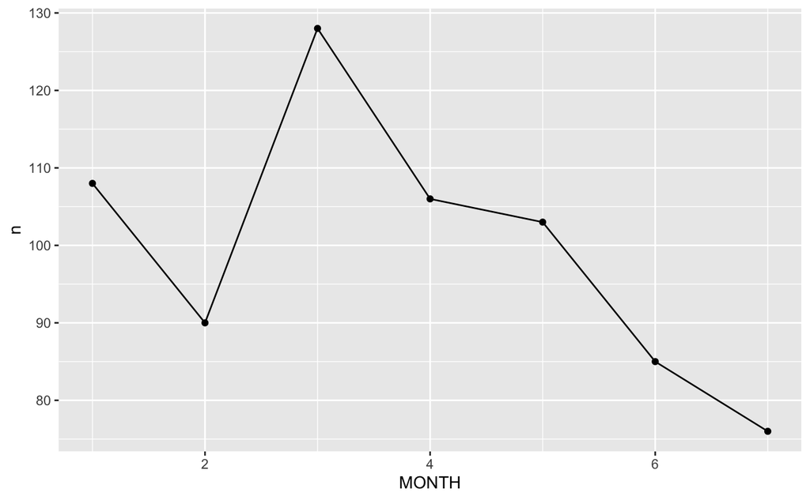

```r
Calfornia2018 %>% filter( TAIL_NUM == "N633VA") %>%
  group_by(MONTH) %>%
  tally() %>%
  ggplot(aes(x = MONTH, y = n)) +
  geom_point() +
  geom_line()
```

Tail number 337NV plane travelled the most times from OAK in 2018.

```r
Calfornia2018 %>% filter ( ORIGIN == "OAK") %>%
 group_by(TAIL_NUM) %>%
  count()%>%
  arrange(desc(n))
```

| TAIL_NUM | n |
| --- | --- |
| 337NV | 90 |
| N202HA | 70 |
| N288WN | 61 |
| N930WN | 61 |
| N273WN | 60 |
| N7742B | 60 |
| N260WN | 57 |
| N551WN | 56 |
| N204HA | 55 |
| N7738A | 55 |

[output cut: 990 more lines]

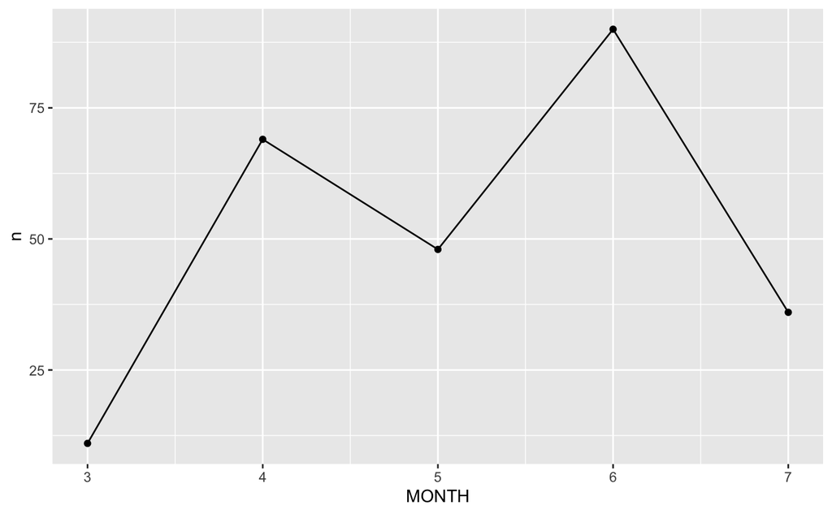

```r
Calfornia2018 %>% filter( TAIL_NUM == "337NV") %>%
  group_by(MONTH) %>%
  tally() %>%
  ggplot(aes(x = MONTH, y = n)) +
  geom_point() +
  geom_line()
```

Tail number N188SY plane travelled the most times from SSJC in 2018.

```r
Calfornia2018 %>% filter ( ORIGIN == "SJC") %>%
 group_by(TAIL_NUM) %>%
  count()%>%
  arrange(desc(n))
```

| TAIL_NUM | n |
| --- | --- |
| N188SY | 179 |
| N186SY | 175 |
| N193SY | 163 |
| N184SY | 144 |
| N189SY | 141 |
| N176SY | 140 |
| N192SY | 138 |
| N194SY | 129 |
| N177SY | 122 |
| N178SY | 122 |

[output cut: 990 more lines]

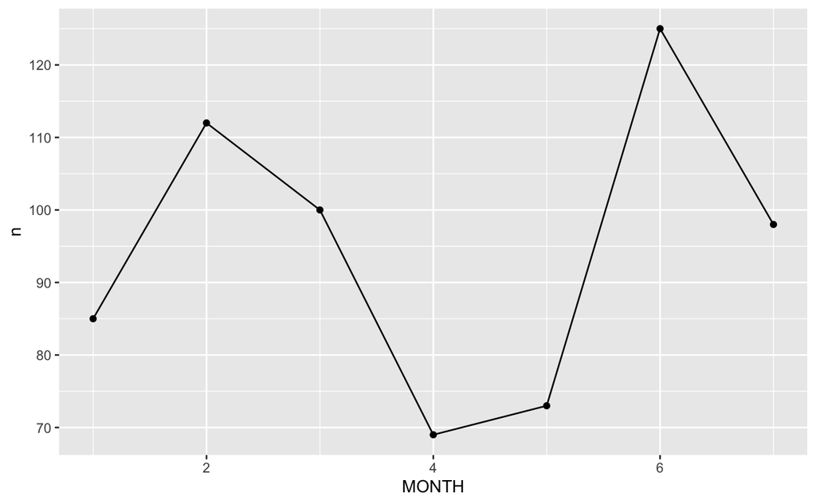

```r
Calfornia2018 %>% filter( TAIL_NUM == "N188SY") %>%
  group_by(MONTH) %>%
  tally() %>%
  ggplot(aes(x = MONTH, y = n)) +
  geom_point() +
  geom_line()
```

**Answer to 4.4:**

Total of 4,114 airplanes that flew from SFO ,OAK ,SJC are included in plane table . 1701 of airplanes from SFO , 1388 of airplanes from SJC and 1025 of airplanes from OAK seperately .

```r
Calfornia2018 %>% head(1)
```

| YEAR | MONTH | DAY_OF_MONTH | FL_DATE | TAIL_NUM | OP_CARRIER_FL_NUM | ORIGIN_AIRPORT_ID | ORIGIN_AIRPORT_SEQ_ID | ORIGIN | ORIGIN_CITY_NAME | ORIGIN_STATE_NM | DEST_AIRPORT_ID | DEST_AIRPORT_SEQ_ID | DEST | DEST_CITY_NAME | DEST_STATE_NM | DEP_TIME | DEP_DELAY | ARR_TIME | ARR_DELAY | AIR_TIME | FLIGHTS | DISTANCE | X24 |
| --- | --- | --- | --- | --- | --- | --- | --- | --- | --- | --- | --- | --- | --- | --- | --- | --- | --- | --- | --- | --- | --- | --- | --- |
| 2018 | 1 | 27 | 2018-01-27 | N477UA | 368 | 14747 | 1474703 | SEA | Seattle, WA | Washington | 14771 | 1477104 | SFO | San Francisco, CA | California | 0614 | -4 | 0813 | -18 | 98 | 1 | 679 | NA |

```r
planes %>% head(1)
```

| tailnum | year | type | manufacturer | model | engines | seats | speed | engine |
| --- | --- | --- | --- | --- | --- | --- | --- | --- |
| N10156 | 2004 | Fixed wing multi engine | EMBRAER | EMB-145XR | 2 | 55 | NA | Turbo-fan |

```r
planes
```

| tailnum | year | type | manufacturer | model | engines | seats | speed | engine |
| --- | --- | --- | --- | --- | --- | --- | --- | --- |
| N10156 | 2004 | Fixed wing multi engine | EMBRAER | EMB-145XR | 2 | 55 | NA | Turbo-fan |
| N102UW | 1998 | Fixed wing multi engine | AIRBUS INDUSTRIE | A320-214 | 2 | 182 | NA | Turbo-fan |
| N103US | 1999 | Fixed wing multi engine | AIRBUS INDUSTRIE | A320-214 | 2 | 182 | NA | Turbo-fan |
| N104UW | 1999 | Fixed wing multi engine | AIRBUS INDUSTRIE | A320-214 | 2 | 182 | NA | Turbo-fan |
| N10575 | 2002 | Fixed wing multi engine | EMBRAER | EMB-145LR | 2 | 55 | NA | Turbo-fan |
| N105UW | 1999 | Fixed wing multi engine | AIRBUS INDUSTRIE | A320-214 | 2 | 182 | NA | Turbo-fan |
| N107US | 1999 | Fixed wing multi engine | AIRBUS INDUSTRIE | A320-214 | 2 | 182 | NA | Turbo-fan |
| N108UW | 1999 | Fixed wing multi engine | AIRBUS INDUSTRIE | A320-214 | 2 | 182 | NA | Turbo-fan |
| N109UW | 1999 | Fixed wing multi engine | AIRBUS INDUSTRIE | A320-214 | 2 | 182 | NA | Turbo-fan |
| N110UW | 1999 | Fixed wing multi engine | AIRBUS INDUSTRIE | A320-214 | 2 | 182 | NA | Turbo-fan |

[output cut: 990 more lines]

```r
planes2 <- planes %>% rename( YEAR = year  )%>%
  rename( TAIL_NUM =tailnum )

planes2
```

| TAIL_NUM | YEAR | type | manufacturer | model | engines | seats | speed | engine |
| --- | --- | --- | --- | --- | --- | --- | --- | --- |
| N10156 | 2004 | Fixed wing multi engine | EMBRAER | EMB-145XR | 2 | 55 | NA | Turbo-fan |
| N102UW | 1998 | Fixed wing multi engine | AIRBUS INDUSTRIE | A320-214 | 2 | 182 | NA | Turbo-fan |
| N103US | 1999 | Fixed wing multi engine | AIRBUS INDUSTRIE | A320-214 | 2 | 182 | NA | Turbo-fan |
| N104UW | 1999 | Fixed wing multi engine | AIRBUS INDUSTRIE | A320-214 | 2 | 182 | NA | Turbo-fan |
| N10575 | 2002 | Fixed wing multi engine | EMBRAER | EMB-145LR | 2 | 55 | NA | Turbo-fan |
| N105UW | 1999 | Fixed wing multi engine | AIRBUS INDUSTRIE | A320-214 | 2 | 182 | NA | Turbo-fan |
| N107US | 1999 | Fixed wing multi engine | AIRBUS INDUSTRIE | A320-214 | 2 | 182 | NA | Turbo-fan |
| N108UW | 1999 | Fixed wing multi engine | AIRBUS INDUSTRIE | A320-214 | 2 | 182 | NA | Turbo-fan |
| N109UW | 1999 | Fixed wing multi engine | AIRBUS INDUSTRIE | A320-214 | 2 | 182 | NA | Turbo-fan |
| N110UW | 1999 | Fixed wing multi engine | AIRBUS INDUSTRIE | A320-214 | 2 | 182 | NA | Turbo-fan |

[output cut: 990 more lines]

```r
planes2 %>% left_join(Calfornia2018, by = c("TAIL_NUM" = "TAIL_NUM")) %>%
  filter(ORIGIN == "SFO" | ORIGIN == "SJC" | ORIGIN == "OAK" )%>%
  group_by(TAIL_NUM,ORIGIN) %>%
  count()
```

| TAIL_NUM | ORIGIN | n |
| --- | --- | --- |
| N102UW | SFO | 1 |
| N103US | OAK | 3 |
| N104UW | OAK | 2 |
| N107US | OAK | 4 |
| N107US | SJC | 1 |
| N109UW | OAK | 1 |
| N110UW | OAK | 1 |
| N111US | OAK | 2 |
| N11206 | SFO | 34 |
| N11206 | SJC | 2 |

[output cut: 990 more lines]

```r
NA
```

1701 of airplanes from SFO are included in the planes table.

```r
Calfornia2018 %>% head(1)
```

| YEAR | MONTH | DAY_OF_MONTH | FL_DATE | TAIL_NUM | OP_CARRIER_FL_NUM | ORIGIN_AIRPORT_ID | ORIGIN_AIRPORT_SEQ_ID | ORIGIN | ORIGIN_CITY_NAME | ORIGIN_STATE_NM | DEST_AIRPORT_ID | DEST_AIRPORT_SEQ_ID | DEST | DEST_CITY_NAME | DEST_STATE_NM | DEP_TIME | DEP_DELAY | ARR_TIME | ARR_DELAY | AIR_TIME | FLIGHTS | DISTANCE | X24 |
| --- | --- | --- | --- | --- | --- | --- | --- | --- | --- | --- | --- | --- | --- | --- | --- | --- | --- | --- | --- | --- | --- | --- | --- |
| 2018 | 1 | 27 | 2018-01-27 | N477UA | 368 | 14747 | 1474703 | SEA | Seattle, WA | Washington | 14771 | 1477104 | SFO | San Francisco, CA | California | 0614 | -4 | 0813 | -18 | 98 | 1 | 679 | NA |

```r
planes %>% head(1)
```

| tailnum | year | type | manufacturer | model | engines | seats | speed | engine |
| --- | --- | --- | --- | --- | --- | --- | --- | --- |
| N10156 | 2004 | Fixed wing multi engine | EMBRAER | EMB-145XR | 2 | 55 | NA | Turbo-fan |

```r
planes2 <- planes %>% rename( YEAR = year  )%>%
  rename( TAIL_NUM =tailnum )

planes2 %>% left_join(Calfornia2018, by = c("TAIL_NUM" = "TAIL_NUM")) %>%
  filter(ORIGIN == "SFO"  )%>%
  group_by(TAIL_NUM,ORIGIN) %>%
  count()
```

| TAIL_NUM | ORIGIN | n |
| --- | --- | --- |
| N102UW | SFO | 1 |
| N11206 | SFO | 34 |
| N1201P | SFO | 9 |
| N12109 | SFO | 48 |
| N12114 | SFO | 52 |
| N12116 | SFO | 61 |
| N12125 | SFO | 61 |
| N12216 | SFO | 38 |
| N12218 | SFO | 62 |
| N12221 | SFO | 44 |

[output cut: 990 more lines]

```r
NA
```

1388 of airplanes from SJC are included in the planes table.

```r
Calfornia2018 %>% head(1)
```

| YEAR | MONTH | DAY_OF_MONTH | FL_DATE | TAIL_NUM | OP_CARRIER_FL_NUM | ORIGIN_AIRPORT_ID | ORIGIN_AIRPORT_SEQ_ID | ORIGIN | ORIGIN_CITY_NAME | ORIGIN_STATE_NM | DEST_AIRPORT_ID | DEST_AIRPORT_SEQ_ID | DEST | DEST_CITY_NAME | DEST_STATE_NM | DEP_TIME | DEP_DELAY | ARR_TIME | ARR_DELAY | AIR_TIME | FLIGHTS | DISTANCE | X24 |
| --- | --- | --- | --- | --- | --- | --- | --- | --- | --- | --- | --- | --- | --- | --- | --- | --- | --- | --- | --- | --- | --- | --- | --- |
| 2018 | 1 | 27 | 2018-01-27 | N477UA | 368 | 14747 | 1474703 | SEA | Seattle, WA | Washington | 14771 | 1477104 | SFO | San Francisco, CA | California | 0614 | -4 | 0813 | -18 | 98 | 1 | 679 | NA |

```r
planes %>% head(1)
```

| tailnum | year | type | manufacturer | model | engines | seats | speed | engine |
| --- | --- | --- | --- | --- | --- | --- | --- | --- |
| N10156 | 2004 | Fixed wing multi engine | EMBRAER | EMB-145XR | 2 | 55 | NA | Turbo-fan |

```r
planes2 <- planes %>% rename( YEAR = year  )%>%
  rename( TAIL_NUM =tailnum )

planes2 %>% left_join(Calfornia2018, by = c("TAIL_NUM" = "TAIL_NUM")) %>%
  filter(ORIGIN == "SJC"  )%>%
  group_by(TAIL_NUM,ORIGIN) %>%
  count()
```

| TAIL_NUM | ORIGIN | n |
| --- | --- | --- |
| N107US | SJC | 1 |
| N11206 | SJC | 2 |
| N12216 | SJC | 3 |
| N12221 | SJC | 1 |
| N12225 | SJC | 1 |
| N12238 | SJC | 4 |
| N13248 | SJC | 2 |
| N13716 | SJC | 3 |
| N13750 | SJC | 4 |
| N14214 | SJC | 5 |

[output cut: 990 more lines]

```r
NA
```

1025 of airplanes from OAK are included in the planes table.

```r
Calfornia2018 %>% head(1)
```

| YEAR | MONTH | DAY_OF_MONTH | FL_DATE | TAIL_NUM | OP_CARRIER_FL_NUM | ORIGIN_AIRPORT_ID | ORIGIN_AIRPORT_SEQ_ID | ORIGIN | ORIGIN_CITY_NAME | ORIGIN_STATE_NM | DEST_AIRPORT_ID | DEST_AIRPORT_SEQ_ID | DEST | DEST_CITY_NAME | DEST_STATE_NM | DEP_TIME | DEP_DELAY | ARR_TIME | ARR_DELAY | AIR_TIME | FLIGHTS | DISTANCE | X24 |
| --- | --- | --- | --- | --- | --- | --- | --- | --- | --- | --- | --- | --- | --- | --- | --- | --- | --- | --- | --- | --- | --- | --- | --- |
| 2018 | 1 | 27 | 2018-01-27 | N477UA | 368 | 14747 | 1474703 | SEA | Seattle, WA | Washington | 14771 | 1477104 | SFO | San Francisco, CA | California | 0614 | -4 | 0813 | -18 | 98 | 1 | 679 | NA |

```r
planes %>% head(1)
```

| tailnum | year | type | manufacturer | model | engines | seats | speed | engine |
| --- | --- | --- | --- | --- | --- | --- | --- | --- |
| N10156 | 2004 | Fixed wing multi engine | EMBRAER | EMB-145XR | 2 | 55 | NA | Turbo-fan |

```r
planes2 <- planes %>% rename( YEAR = year  )%>%
  rename( TAIL_NUM =tailnum )

planes2 %>% left_join(Calfornia2018, by = c("TAIL_NUM" = "TAIL_NUM")) %>%
  filter(ORIGIN == "OAK"  )%>%
  group_by(TAIL_NUM,ORIGIN) %>%
  count()
```

| TAIL_NUM | ORIGIN | n |
| --- | --- | --- |
| N103US | OAK | 3 |
| N104UW | OAK | 2 |
| N107US | OAK | 4 |
| N109UW | OAK | 1 |
| N110UW | OAK | 1 |
| N111US | OAK | 2 |
| N112US | OAK | 2 |
| N117UW | OAK | 3 |
| N118US | OAK | 1 |
| N119US | OAK | 2 |

[output cut: 990 more lines]

#for my second part of project , i used the Violations data set in the mdsr package contains information regarding the out- come of health inspections of restaurants in New York City. It is a data frame with 480,621 observations on the following 16 variables.

```r
library(mdsr)
```

```r
Violations
```

| camis | dba | boro | building | street | zipcode | phone | inspection_date | action | violation_code | score | grade | grade_date | record_date | inspection_type | cuisine_code |
| --- | --- | --- | --- | --- | --- | --- | --- | --- | --- | --- | --- | --- | --- | --- | --- |
| 30075445 | MORRIS PARK BAKE SHOP | BRONX | 1007 | MORRIS PARK AVE | 10462 | 7188924968 | 2015-02-09 | Violations were cited in the following area(s). | 06C | 6 | A | 2015-02-09 | 2016-01-06 | Cycle Inspection / Initial Inspection | 8 |
| 30075445 | MORRIS PARK BAKE SHOP | BRONX | 1007 | MORRIS PARK AVE | 10462 | 7188924968 | 2014-03-03 | Violations were cited in the following area(s). | 10F | 2 | A | 2014-03-03 | 2016-01-06 | Cycle Inspection / Initial Inspection | 8 |
| 30075445 | MORRIS PARK BAKE SHOP | BRONX | 1007 | MORRIS PARK AVE | 10462 | 7188924968 | 2013-10-10 | No violations were recorded at the time of this inspection. | NA | NA | NA |  | 2016-01-06 | Trans Fat / Second Compliance Inspection | 8 |
| 30075445 | MORRIS PARK BAKE SHOP | BRONX | 1007 | MORRIS PARK AVE | 10462 | 7188924968 | 2013-09-11 | Violations were cited in the following area(s). | 04L | 6 | A | 2013-09-11 | 2016-01-06 | Cycle Inspection / Re-inspection | 8 |
| 30075445 | MORRIS PARK BAKE SHOP | BRONX | 1007 | MORRIS PARK AVE | 10462 | 7188924968 | 2013-09-11 | Violations were cited in the following area(s). | 04N | 6 | A | 2013-09-11 | 2016-01-06 | Cycle Inspection / Re-inspection | 8 |
| 30075445 | MORRIS PARK BAKE SHOP | BRONX | 1007 | MORRIS PARK AVE | 10462 | 7188924968 | 2013-08-14 | Violations were cited in the following area(s). | 04C | 32 | NA |  | 2016-01-06 | Cycle Inspection / Initial Inspection | 8 |
| 30075445 | MORRIS PARK BAKE SHOP | BRONX | 1007 | MORRIS PARK AVE | 10462 | 7188924968 | 2013-08-14 | Violations were cited in the following area(s). | 04L | 32 | NA |  | 2016-01-06 | Cycle Inspection / Initial Inspection | 8 |
| 30075445 | MORRIS PARK BAKE SHOP | BRONX | 1007 | MORRIS PARK AVE | 10462 | 7188924968 | 2013-08-14 | Violations were cited in the following area(s). | 06A | 32 | NA |  | 2016-01-06 | Cycle Inspection / Initial Inspection | 8 |
| 30075445 | MORRIS PARK BAKE SHOP | BRONX | 1007 | MORRIS PARK AVE | 10462 | 7188924968 | 2013-08-14 | Violations were cited in the following area(s). | 06C | 32 | NA |  | 2016-01-06 | Cycle Inspection / Initial Inspection | 8 |
| 30075445 | MORRIS PARK BAKE SHOP | BRONX | 1007 | MORRIS PARK AVE | 10462 | 7188924968 | 2013-08-14 | Violations were cited in the following area(s). | 08A | 32 | NA |  | 2016-01-06 | Cycle Inspection / Initial Inspection | 8 |

[output cut: 990 more lines]

##2.What new variables do you now also have. Make a table of the variables that are in the new dataset with a description of each variable.

**Answer :**In Violation data set I have 16 variables , below is variable name with its description .

| Variable name | variable discription |
| --- | --- |
| camis | unique identifier |
| dba | full name doing business as |
| boro | borough of New York |
| building | building name |
| street | street address |
| zipcode | zipcode |
| phone | phone number |
| inspection_date | inspection date |
| action | action taken |
| violation_code | violation code |
| score | inspection score |
| grade | inspection grade |
| grade_date | grade date |
| record_date | recording date |
| inspection_type | inspect type |
| cuisine_code | cuisine code |

##3. How many cuisine are graded with A ,B ,C ?

**Answer :** There were 162362 cuisines graded with A , 40121 cuisines graded with B and 11501 graded with C .

```r
  Violations %>%filter(grade=="A") %>%
  group_by(grade)%>%
 count()
```

| grade | n |
| --- | --- |
| A | 162362 |

```r
NA
```

```r
  Violations %>%filter(grade=="C") %>%
  group_by(grade)%>%
 count()
```

| grade | n |
| --- | --- |
| C | 11501 |

```r
NA
```

```r
  Violations %>%filter(grade=="B") %>%
  group_by(grade)%>%
 count()
```

| grade | n |
| --- | --- |
| B | 40121 |

```r
NA
```

```r
  Violations %>% select( zipcode , score ) %>%
  group_by(zipcode)%>%
 summarize( n=n(), score_max=max(score, na.rm = TRUE) )%>%
  arrange(desc(score_max))
```

| zipcode | n | score_max |
| --- | --- | --- |
| 10022 | 8853 | 156 |
| 11372 | 7434 | 132 |
| 10019 | 12007 | 131 |
| 10002 | 9113 | 122 |
| 10018 | 6414 | 121 |
| 11354 | 7827 | 121 |
| 10036 | 11226 | 117 |
| 11226 | 3994 | 115 |
| 11413 | 721 | 115 |
| 10006 | 977 | 111 |

[output cut: 219 more lines]

```r
NA
NA
NA
```

```r
  Violations %>% select( zipcode , score ) %>%
  group_by(zipcode)%>%
 summarize( n=n(), score_min=min(score, na.rm = TRUE) )%>%
  arrange((score_min))
```

| zipcode | n | score_min |
| --- | --- | --- |
| 11218 | 2941 | -2 |
| 10001 | 8420 | -1 |
| 10002 | 9113 | -1 |
| 10010 | 4658 | -1 |
| 10011 | 8790 | -1 |
| 10012 | 8048 | -1 |
| 10013 | 10152 | -1 |
| 10014 | 8440 | -1 |
| 10016 | 9083 | -1 |
| 10017 | 6730 | -1 |

[output cut: 219 more lines]

```r
NA
NA
NA
```

##5. #. Of the cuisines with grade of A and B, what proportion of these cuisines are between the score of 20 or more and less than 40 ?

**Answer:** 11.31 % of score which is from 20 to 40

```r
Violations%>% filter(grade == "A" |grade == "B" ) %>%
  summarize(n=n(), mean( score >= 20& score < 40 ))
```

| n | mean(score >= 20 & score < 40) |
| --- | --- |
| 202483 | 0.1131947 |

```r
NA
```

##6. Which dba(full name doing business as) had the highest number of grade with A ?

**Answer:** DUNKIN’ DONUTS is the highest number of grade with A which is 2936

```r
Violations %>%
  group_by(dba,grade) %>%
  count() %>%
  arrange(desc(n))
```

| dba | grade | n |
| --- | --- | --- |
| DUNKIN' DONUTS | A | 2936 |
| SUBWAY | A | 2638 |
| SUBWAY | NA | 2070 |
| MCDONALD'S | NA | 1966 |
| MCDONALD'S | A | 1877 |
| DUNKIN' DONUTS | NA | 1831 |
| STARBUCKS | A | 1709 |
| DUNKIN' DONUTS, BASKIN ROBBINS | A | 1004 |
| CROWN FRIED CHICKEN | NA | 923 |
| DUNKIN' DONUTS, BASKIN ROBBINS | NA | 811 |

[output cut: 990 more lines]

##7.What was the mean score of the cuisine? What was the mean score of the cuisine that is graded with A? What was the mean score of the cuisine that is graded with B?What was the mean score of the cuisine that is graded with C ? **Answer:** The mean score of cuisines was 20.042, the mean score of cuisines that was graded by A is 9.799 ,the mean score of cuisines that was graded by B is 20.569 and the mean score of cuisines that was graded by C is 36.987 .

```r
Violations %>% select(score) %>%
  summarize(n=n(),  score_mean=mean(score, na.rm=TRUE))
```

| n | score_mean |
| --- | --- |
| 480621 | 20.04248 |

```r
Violations%>% select(grade, score) %>%
  group_by(grade) %>%
  summarize(score_mean=mean(score, na.rm=TRUE))
```

| grade | score_mean |
| --- | --- |
| A | 9.799153 |
| B | 20.569054 |
| C | 36.986958 |
| Not Yet Graded | 22.712521 |
| P | 6.965613 |
| Z | 25.294383 |
| NA | 26.372898 |

##8.What Type of grade more?  
**Answer:** grade type with A more than other grade type .

```r
Violations%>%
  group_by(grade) %>%
 summarise(n=n())
```

| grade | n |
| --- | --- |
| A | 162362 |
| B | 40121 |
| C | 11501 |
| Not Yet Graded | 1217 |
| P | 1803 |
| Z | 3329 |
| NA | 260288 |